# Anàlisi de Factors Clau que Influeixen en el Preu dels Habitatges a Washington

Marc Bracons Cucó

19 de mayo, 2024

# 1. Introducció

En aquest estudi usarem el conjunt de dades **Casas** sobre les característiques i preus d’habitatges de l’estat de Washington en USA. S’han recollit dades dels habitatges, com a superfície útil, nombre de banys i lavabos, superfície de la parcel·la, etc,. També es té informació sobre variables de l’entorn, com a vistes i proximitat dels veïns. L’objectiu principal d’aquest estudi és esbrinar quins són els factors que més influeixen a l’hora de determinar el preu d’una casa. Aquest tipus d’anàlisi és molt útil tant per a les agències, com per al mercat immobiliari en general, per a poder predir l’evolució del preu dels habitatges.

L’arxiu conté aproximadament 21600 registres i 16 variables. Les principals variables són:

- date: Data de venda
- price: Preu de venda
- bedrooms: Nombre d’habitacions
- bathrooms: Nombre de banys/lavabos
- sqtf_living: Superfície habitable (en peus al quadrat)
- sqft_lot: Superfície de la parcel·la (en peus al quadrat)
- floors: Nombre de plantes
- waterfront: Indica si l’habitatge té accés a un llac
- view: Tipus de vista (variable numèrica)
- condition: Estat de l’habitatge, codificada de l’1 al 5, sent 1 Molt mala i 5 Molt bona
- sqft_basement: Superfície del soterrani (en peus al quadrat)
- yr_built: Any de construcció de l’habitatge
- yr_renovated: Any de renovació de l’habitatge
- sqft_living15: Superfície habitable mitjana dels 15 veïns més pròxims
- sqft_lot15: Superfície de la parcel·la mitjana dels 15 veïns més pròxims.

Primer s’estudiaran les possibles relacions lineals entre el preu de l’habitatge i les diferents variables independents. En la segona part de l’activitat es buscaran els possibles factors que intervenen perquè un habitatge tingui un preu més elevat i sigui considerada de luxe. Segons les dades d’aquest estudi el preu mitjà seria de 450000$.

# Regressió Lineal

## Preparació de les dades

```r
cases <- read.csv("Casas.csv")
head(cases)
```

```
##              date   price bedrooms bathrooms sqft_living sqft_lot floors
## 1 20141013T000000  221900        3      1.00        1180     5650      1
## 2 20141209T000000  538000        3      2.25        2570     7242      2
## 3 20150225T000000  180000        2      1.00         770    10000      1
## 4 20141209T000000  604000        4      3.00        1960     5000      1
## 5 20150218T000000  510000        3      2.00        1680     8080      1
## 6 20140512T000000 1230000        4      4.50        5420   101930      1
##   waterfront view condition sqft_basement yr_built yr_renovated zipcode
## 1          0    0         3             0     1955            0   98178
## 2          0    0         3           400     1951         1991   98125
## 3          0    0         3             0     1933            0   98028
## 4          0    0         5           910     1965            0   98136
## 5          0    0         3             0     1987            0   98074
## 6          0    0         3          1530     2001            0   98053
##   sqft_living15 sqft_lot15
## 1          1340       5650
## 2          1690       7639
## 3          2720       8062
## 4          1360       5000
## 5          1800       7503
## 6          4760     101930
```

Abans de començar amb l’anàlisi es passaran les variables de superfície mesures en peus quadrats a metres quadrats i els dòlars a euros. Això es fa tenint en compte les conversions següents:

$1\_peusquadrats=0.0929\_metresquadrats$

$1\_dolar=0.93\_euros$

```r
# Constants de conversió
peus_a_metres <- 0.0929
dolars_a_euros <- 0.93

# Conversió de superfície de peus quadrats a metres quadrats i canvi de noms
cases$m2_living <- cases$sqft_living * peus_a_metres
cases$m2_lot <- cases$sqft_lot * peus_a_metres
cases$m2_basement <- cases$sqft_basement * peus_a_metres
cases$m2_living15 <- cases$sqft_living15 * peus_a_metres
cases$m2_lot15 <- cases$sqft_lot15 * peus_a_metres

# Eliminem les columnes originals en peus quadrats
cases$sqft_living <- NULL
cases$sqft_lot <- NULL
cases$sqft_basement <- NULL
cases$sqft_living15 <- NULL
cases$sqft_lot15 <- NULL

# Conversió de dòlars a euros i canvi de nom de la columna
cases$price_euros <- cases$price * dolars_a_euros
cases$price <- NULL

# Mostrem les primeres files per verificar les conversions i els nous noms de les columnes
head(cases[, c("m2_living", "m2_lot", "m2_basement", "m2_living15", "m2_lot15", "price_euros")])
```

```
##   m2_living    m2_lot m2_basement m2_living15  m2_lot15 price_euros
## 1   109.622  524.8850       0.000     124.486  524.8850      206367
## 2   238.753  672.7818      37.160     157.001  709.6631      500340
## 3    71.533  929.0000       0.000     252.688  748.9598      167400
## 4   182.084  464.5000      84.539     126.344  464.5000      561720
## 5   156.072  750.6320       0.000     167.220  697.0287      474300
## 6   503.518 9469.2970     142.137     442.204 9469.2970     1143900
```

A continuació revisem la naturalesa de cadascuna de les variables a estudiar, també comprovarem si és necessari algun canvi.

```r
str(cases)
```

```
## 'data.frame':    21613 obs. of  16 variables:
##  $ date        : chr  "20141013T000000" "20141209T000000" "20150225T000000" "20141209T000000" ...
##  $ bedrooms    : int  3 3 2 4 3 4 3 3 3 3 ...
##  $ bathrooms   : num  1 2.25 1 3 2 4.5 2.25 1.5 1 2.5 ...
##  $ floors      : num  1 2 1 1 1 1 2 1 1 2 ...
##  $ waterfront  : int  0 0 0 0 0 0 0 0 0 0 ...
##  $ view        : int  0 0 0 0 0 0 0 0 0 0 ...
##  $ condition   : int  3 3 3 5 3 3 3 3 3 3 ...
##  $ yr_built    : int  1955 1951 1933 1965 1987 2001 1995 1963 1960 2003 ...
##  $ yr_renovated: int  0 1991 0 0 0 0 0 0 0 0 ...
##  $ zipcode     : int  98178 98125 98028 98136 98074 98053 98003 98198 98146 98038 ...
##  $ m2_living   : num  109.6 238.8 71.5 182.1 156.1 ...
##  $ m2_lot      : num  525 673 929 464 751 ...
##  $ m2_basement : num  0 37.2 0 84.5 0 ...
##  $ m2_living15 : num  124 157 253 126 167 ...
##  $ m2_lot15    : num  525 710 749 464 697 ...
##  $ price_euros : num  206367 500340 167400 561720 474300 ...
```

Observem que s’ha de canviar el tipus de la variable **date** a *Date* i el de **waterfront**, **view** i **condition** a *factor*.

```r
cases$date <- as.Date(cases$date, format="%Y%m%dT%H%M%S")
 cases$waterfront <- as.factor(cases$waterfront)
 cases$view <- as.factor(cases$view)
 cases$condition <- as.factor(cases$condition)
```

Tornem a mirar el tipus de variables per verificar que els canvis s’han dut a terme correctament.

```r
str(cases)
```

```
## 'data.frame':    21613 obs. of  16 variables:
##  $ date        : Date, format: "2014-10-13" "2014-12-09" ...
##  $ bedrooms    : int  3 3 2 4 3 4 3 3 3 3 ...
##  $ bathrooms   : num  1 2.25 1 3 2 4.5 2.25 1.5 1 2.5 ...
##  $ floors      : num  1 2 1 1 1 1 2 1 1 2 ...
##  $ waterfront  : Factor w/ 2 levels "0","1": 1 1 1 1 1 1 1 1 1 1 ...
##  $ view        : Factor w/ 5 levels "0","1","2","3",..: 1 1 1 1 1 1 1 1 1 1 ...
##  $ condition   : Factor w/ 5 levels "1","2","3","4",..: 3 3 3 5 3 3 3 3 3 3 ...
##  $ yr_built    : int  1955 1951 1933 1965 1987 2001 1995 1963 1960 2003 ...
##  $ yr_renovated: int  0 1991 0 0 0 0 0 0 0 0 ...
##  $ zipcode     : int  98178 98125 98028 98136 98074 98053 98003 98198 98146 98038 ...
##  $ m2_living   : num  109.6 238.8 71.5 182.1 156.1 ...
##  $ m2_lot      : num  525 673 929 464 751 ...
##  $ m2_basement : num  0 37.2 0 84.5 0 ...
##  $ m2_living15 : num  124 157 253 126 167 ...
##  $ m2_lot15    : num  525 710 749 464 697 ...
##  $ price_euros : num  206367 500340 167400 561720 474300 ...
```

## Estudi de correlació lineal

Una vegada efectuades les conversions, és el moment de calcar la correlació lineal entre totes les variables de l’estudi, exceptuant date y zipcode. Una vegada calculades les correlacions, mostrarem, en forma de matriu, només aquelles que tinguin un coeficient de correlació superior a 0.2. A més les ordenarem de manera decreixent, és a dir del valor més alt de r, al més baix, per facilitar-ne la lectura.

A part de les columnes a ignorar mencionades anteriorment, tampoc hi posem les de tipus factor. Per a la representació, eliminem les correlacions simètriques $corr(a,b)=corr(b,a)$, deixant només el càlcul d’una de les parelles. Tampoc mostrarem les correlacions d’una variable amb si mateixa ($corr(a,a)$).

```r
library(reshape2)

columnes_a_ignorar <- c("date", "zipcode", "waterfront", "view", "condition")
cases_filtrades <- cases[, !(names(cases) %in% columnes_a_ignorar)]

# matriu_correlacio
matriu_correlacio <- cor(cases_filtrades)

# Filtrem valor absolut superior a 0.2
matriu_correlacio[abs(matriu_correlacio) < 0.2] <- NA

correlacio_melted <- melt(matriu_correlacio, na.rm = TRUE)
correlacio_melted <- correlacio_melted[correlacio_melted$Var1 != correlacio_melted$Var2, ]
correlacio_melted <- correlacio_melted[!duplicated(t(apply(correlacio_melted[, c("Var1", "Var2")], 1, sort))), ]
correlacio_melted <- correlacio_melted[order(-abs(correlacio_melted$value)),]

print(correlacio_melted)
```

```
##            Var1        Var2      value
## 64  m2_living15   m2_living  0.7564203
## 17    m2_living   bathrooms  0.7546653
## 76     m2_lot15      m2_lot  0.7185568
## 66  price_euros   m2_living  0.7020437
## 99  price_euros m2_living15  0.5853740
## 6     m2_living    bedrooms  0.5766707
## 20  m2_living15   bathrooms  0.5686343
## 22  price_euros   bathrooms  0.5251341
## 2     bathrooms    bedrooms  0.5158836
## 15     yr_built   bathrooms  0.5060194
## 14       floors   bathrooms  0.5006532
## 26     yr_built      floors  0.4893194
## 63  m2_basement   m2_living  0.4350430
## 9   m2_living15    bedrooms  0.3916375
## 28    m2_living      floors  0.3539493
## 42  m2_living15    yr_built  0.3262289
## 88  price_euros m2_basement  0.3238374
## 39    m2_living    yr_built  0.3180488
## 11  price_euros    bedrooms  0.3083384
## 8   m2_basement    bedrooms  0.3030934
## 19  m2_basement   bathrooms  0.2837700
## 31  m2_living15      floors  0.2798853
## 33  price_euros      floors  0.2567857
## 30  m2_basement      floors -0.2457045
## 38 yr_renovated    yr_built -0.2248735
## 86  m2_living15 m2_basement  0.2003550
```

## Generació dels conjunts d’entrenament i de test

Per a poder estimar de forma més objectiva la precisió del model lineal, separarem el conjunt de dades en dues parts: el conjunt d’entrenament (training) i el conjunt de prova (testing). Ajustarem el model de regressió lineal amb el conjunt d’entrenament, i avaluarem la precisió amb el conjunt de prova.

```r
# Fixem una llavor per poder reproduïr els resultats
set.seed(42)

# Calculem la mida de la mostra d'entrenament
mida_entrenament <- floor(0.8 * nrow(cases))

index_aleatori <- sample(seq_len(nrow(cases)), size = mida_entrenament)

# Dividim el conjunt de dades
conjunt_entrenament <- cases[index_aleatori, ]
conjunt_prova <- cases[-index_aleatori, ]
```

## Estimació del model de regressió lineal

A continuació estimarem per mínims quadrats ordinaris un model lineal que expliqui el preu dels habitatges en funció de totes les variables utilitzades per a calcular les correlacions en l’apartat anterior.

```r
conjunt_entrenament_filtrat <- conjunt_entrenament[, !(names(conjunt_entrenament) %in% columnes_a_ignorar)]

# Construïm el model utilitzant el conjunt d'entrenament
model <- lm(price_euros ~ ., data = conjunt_entrenament_filtrat)

summary(model)
```

```
##
## Call:
## lm(formula = price_euros ~ ., data = conjunt_entrenament_filtrat)
##
## Residuals:
##      Min       1Q   Median       3Q      Max
## -1269888  -119587   -14482    91212  3796775
##
## Coefficients:
##                Estimate Std. Error t value Pr(>|t|)
## (Intercept)   6.251e+06  1.458e+05  42.868  < 2e-16 ***
## bedrooms     -5.789e+04  2.259e+03 -25.630  < 2e-16 ***
## bathrooms     6.561e+04  3.973e+03  16.513  < 2e-16 ***
## floors        5.113e+04  4.252e+03  12.025  < 2e-16 ***
## yr_built     -3.251e+03  7.575e+01 -42.919  < 2e-16 ***
## yr_renovated  2.530e+01  4.424e+00   5.719 1.09e-08 ***
## m2_living     2.415e+03  4.432e+01  54.504  < 2e-16 ***
## m2_lot        5.636e-01  5.945e-01   0.948    0.343
## m2_basement   6.420e+01  5.449e+01   1.178    0.239
## m2_living15   9.554e+02  4.223e+01  22.624  < 2e-16 ***
## m2_lot15     -7.151e+00  9.499e-01  -7.528 5.40e-14 ***
## ---
## Signif. codes:  0 '***' 0.001 '**' 0.01 '*' 0.05 '.' 0.1 ' ' 1
##
## Residual standard error: 220900 on 17279 degrees of freedom
## Multiple R-squared:  0.5711, Adjusted R-squared:  0.5709
## F-statistic:  2301 on 10 and 17279 DF,  p-value: < 2.2e-16
```

S’ha de tindre en compte els valors 0.5711 de **Multiple R-squared** i 0.5709 de **Adjusted R-suqared**, que ens indiquen que el model explica un 57% de la variació en els preus. No és un valor molt alt així que pot ser que hi hagi altres factors importants a tindre en compte.

### Comprovació de col·linealitat

Una vegada ajustat el model comprovarem la presència o no de col·linealitat. A la vista dels resultats, decidirem si es pot excloure alguna variable del model.

Per a la comprovació de la col·linealitat, compararem els valors del factor de inflacció de la variància (FIV), amb el seu equivalent en el model ajustat. Els valors FIV majors que aquesta quantitat impliquen que la relació entre les variables explicatives és major que la que existeix entre la resposta i els predictors, i per tant donen indicis de multicol·linealitat.

```r
library(car)
vif_values <- vif(model)
print(vif_values)
```

```
##     bedrooms    bathrooms       floors     yr_built yr_renovated    m2_living
##     1.570725     3.279509     1.872935     1.752846     1.102271     5.031159
##       m2_lot  m2_basement  m2_living15     m2_lot15
##     2.001653     1.781639     2.547604     2.035057
```

Tenint en compte que el coeficient de determinació ($R^2$) del model complet és 0.5711, podem calcular el seu equivalent en el model ajustat:

$FIV_{límit}=\frac{1}{1-R^2}=\frac{1}{1-0.5711}=2.332$

Els valors del FIV de les variables oscil·len entre 1.1 i 5, sient aquest últim el de **m2_living**, un valor per sobre del límit calculat, així doncs, hi ha una forta colinealitat amb altres variables.

Altres variables com **bathrooms** o **m2_living15** estan per sobre del límit, i eliminar-les, podria afectar negativament el model.

## Diagnosi del model

Per a la diagnosi es tria el model final construït en l’apartat anterior, una vegada decidit si s’elimina o no alguna variable per problemes de col·linealitat. Generarem un histograma amb els residus ( valors observats menys els predits pel model) i posteriorment altres dos gràfics: un amb els valors ajustats enfront dels residus (que ens permetrà veure si la variància és constant) i el gràfic quantil-quantil que compara els residus del model amb els valors d’una variable que es distribueix normalment (QQ plot).

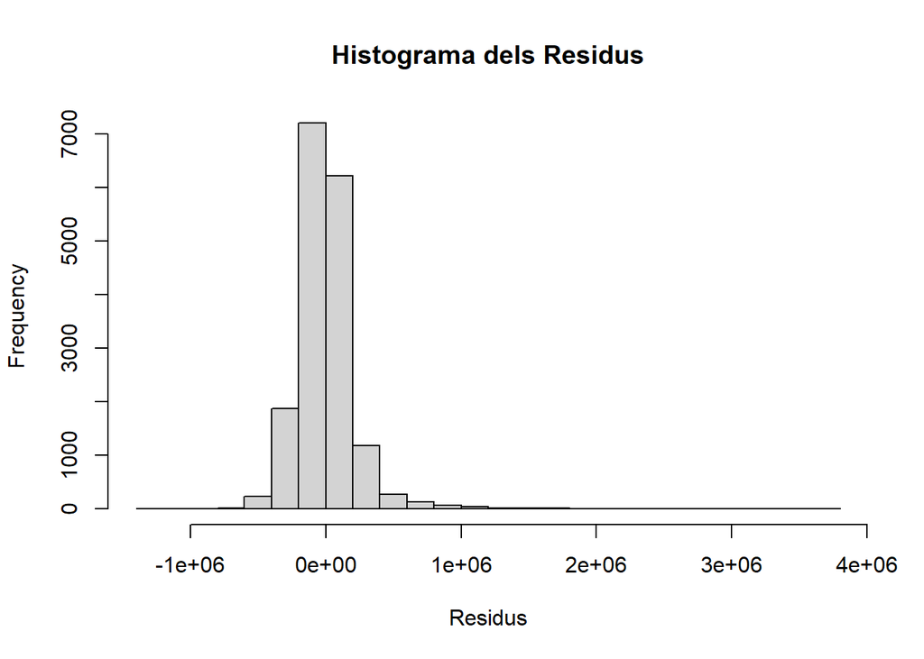

```r
# Generem prediccions i residus
residus <- residuals(model)

# Histograma dels residus
hist(residus, breaks = 30, main = "Histograma dels Residus", xlab = "Residus")
```

A l’histograma dels residus hi veiem que la majoria dels residus es concentren al voltant del zero. Es pot veure una distribució lleugerament asimètrica. Existeixen valors extrems tant al costat positiu com al negatiu, pot ser que hi hagi alguns outliers. Tot i no ser perfecte, la forma recorda a la d’una distribució normal.

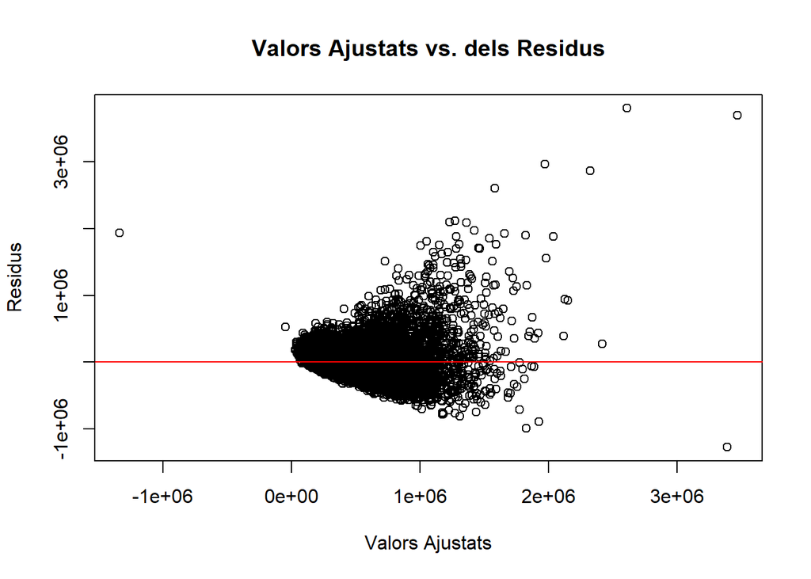

```r
# Gràfic de valors ajustats vs. dels residus
plot(model$fitted.values, residus,
     main = "Valors Ajustats vs. dels Residus",
     xlab = "Valors Ajustats",
     ylab = "Residus")
abline(h = 0, col = "red")
```

En aquesta gràfica podem veure que els residus no estan distribuïts de manera completament aleatòria al voltant de la línia d’alçada 0. Podem veure que per a valor més petits les mostres estan més agrupades i quan aquests augmenten, la dispersió també ho fa. Això es deu al fet que la variància dels errors no és constant al llarg de les prediccions fetes, cosa que pot afectar a la precisió del model.

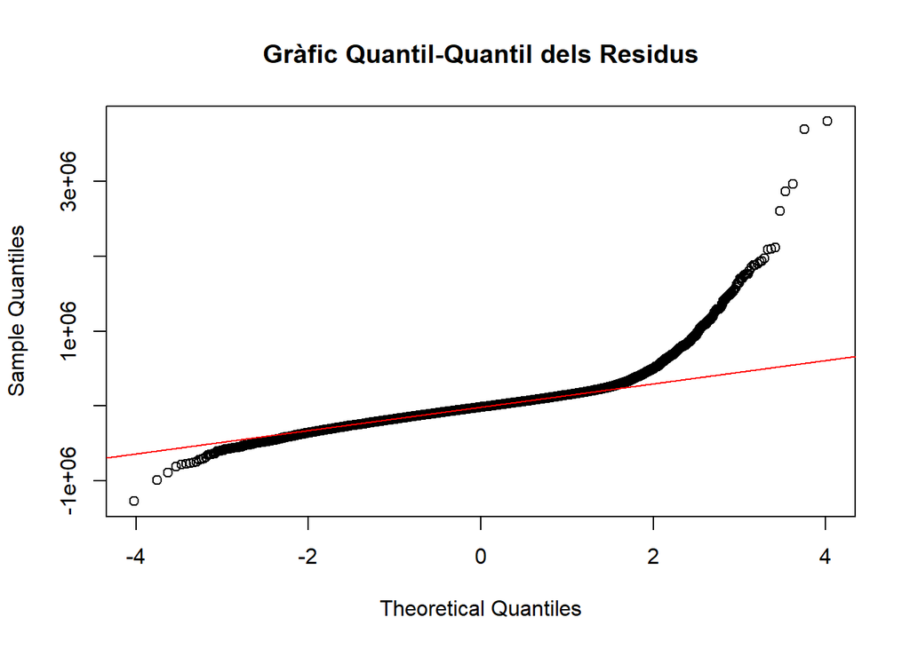

```r
# Gràfic Quantil-Quantil
qqnorm(residus, main = "Gràfic Quantil-Quantil dels Residus")
qqline(residus, col = "red")
```

El gràfic Quantil-Quantil ens mostra que els residus segueixen una línia recta, tot i haver-hi desviacions significatives als extrems. Per tant, els residus no segueixen de forma estricta una distribució normal.

Amb tota aquesta informació podem dir que els residus no segueixen exactament una distribució normal i que la variància dels residus no és constant, cosa que pot afectar la fiabilitat de les estimacions.

## Predicció del model

Segons el model final, calcularem les prediccions del preu que tindria un habitatge, utilitzant la base de dades de testing. Representarem els valors predits enfront els valors observats. Avaluarem la precisió del model mitjançant l’arrel quadrada de l’error quadràtic mitjà (RMSE).

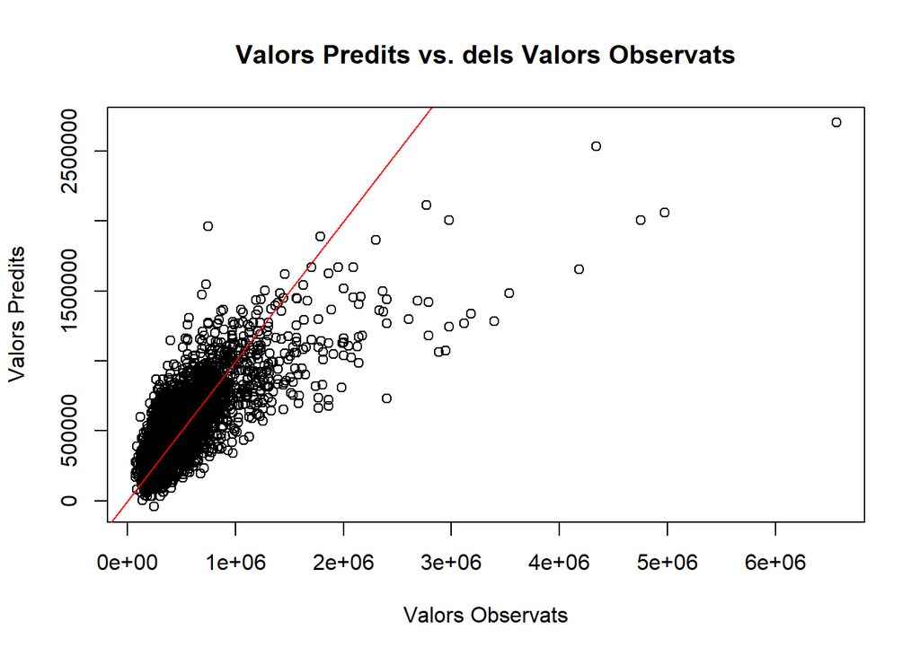

```r
# Càlcul de les prediccions
conjunt_prova_filtrat <- conjunt_prova[, !(names(conjunt_prova) %in% columnes_a_ignorar)]
prediccions <- predict(model, conjunt_prova_filtrat)

# Gràfic de valors predits vs. dels valors observats
plot(conjunt_prova$price_euros, prediccions,
     main = "Valors Predits vs. dels Valors Observats",
     xlab = "Valors Observats",
     ylab = "Valors Predits")
abline(0, 1, col = "red")
```

```r
# RMSE
error <- conjunt_prova$price_euros - prediccions
rmse <- sqrt(mean(error^2))
print(paste("RMSE: ", rmse))
```

```
## [1] "RMSE:  236655.40780938"
```

El gràfic ens mostra la relació entre les prediccions i els valors observats. Els punts ideals són els que estan sobre la línia vermella ($y=x$), que indicaria una predicció perfecta.

Hi podem observar una dispersió considerable al voltant de la línia de referència, sobretot a mesura que els valors observats augmenten. És a dir, el model té problemes en fer prediccions sobre els habitatges més cars. Sembla que hi ha més punts per sota de la línia de referència, indicant que el model tendeix a subestimar el preu de l’habitatge (accentuat encara més en els habitatges grans). Finalment, hi podem veure outliers, tant en valors observats com en prediccions.

Pel que fa al RMSE, el seu valor calculat és 236655, cosa que ens indica el valor en què, en mijtana les prediccions del model es desvien dels valors observats. Tenint en compte que el valor mitja del conjunt és al voltant dels 450000€, això suposa un error molt alt (>50%). Per tant, podem dir que el model no és molt precís.

# Regressió logística

## Preparació de les dades

Es vol estudiar quins són els factors que més influeixen en el preu de l’habitatge en l’estat de Washington.

Per a això, primer crearem una nova variable dicotòmica anomenada **price_re**. Aquesta nova variable està relacionada amb els valors de la variable *price_eur*. La codificarem de la manera següent: *“preu inferior a 500000 euros” pren el valor 0* i *“preu superior o igual a 500000” el valor 1*. Per al model de regressió logística, es prendrà com a variable dependent *price_re*.

De manera anàloga als models lineals, separarem el conjunt de dades en dues parts: el conjunt d’entrenament (training2) i el conjunt de prova (testing2). Ajustarem el model de regressió logística amb el conjunt d’entrenament, i avaluarem la precisió amb el conjunt de prova.

```r
# Creació de la variable dicotòmica price_re
cases$price_re <- ifelse(cases$price_euros >= 500000, 1, 0)
```

```r
# Separem el conjunt de dades en entrenament i prova (80% i 20%)
set.seed(42)

mida_entrenament2 <- floor(0.8 * nrow(cases))

index_aleatori2 <- sample(seq_len(nrow(cases)), size = mida_entrenament2)

conjunt_entrenament2 <- cases[index_aleatori2, ]
conjunt_prova2 <- cases[-index_aleatori2, ]
```

## Estimació del model de regressió logística

Prenent com a base, training2, estimem el model de regressió logística sent la variable dependent **price_re** i prenent com a variables explicatives les triades en el model de regressió lineal final. Tenim en compte que la variable **price_eur** sense recodificar cal eliminar-la com a variable explicativa. A més la nova variable **price_re**, com les variables **view** i **waterfront** han de ser transformades a factor. A la vista dels resultats, decidirem si eliminar o no algun dels factors del model. A aquest model triat, se’n dirà model final.

```r
# Transformem les variables en factors
conjunt_entrenament2$price_re <- as.factor(conjunt_entrenament2$price_re)
conjunt_entrenament2$view <- as.factor(conjunt_entrenament2$view)
conjunt_entrenament2$waterfront <- as.factor(conjunt_entrenament2$waterfront)

# Filtrem les columnes no desitjades (incloem price_euros)
columnes_a_ignorar_logistic <- c("price_euros", "date", "zipcode", "condition")
conjunt_entrenament_filtrat2 <- conjunt_entrenament2[, !(names(conjunt_entrenament2) %in% columnes_a_ignorar_logistic)]
```

```r
# Ajust del model de regressió logística
model_logistic <- glm(price_re ~ ., data = conjunt_entrenament_filtrat2, family = binomial)

summary(model_logistic)
```

```
##
## Call:
## glm(formula = price_re ~ ., family = binomial, data = conjunt_entrenament_filtrat2)
##
## Coefficients:
##                Estimate Std. Error z value Pr(>|z|)
## (Intercept)   5.890e+01  1.947e+00  30.248  < 2e-16 ***
## bedrooms     -2.979e-01  2.991e-02  -9.960  < 2e-16 ***
## bathrooms     6.113e-01  5.229e-02  11.690  < 2e-16 ***
## floors        8.425e-01  5.634e-02  14.954  < 2e-16 ***
## waterfront1   3.001e-01  4.621e-01   0.649  0.51605
## view1         7.926e-01  1.726e-01   4.592 4.40e-06 ***
## view2         5.500e-01  1.027e-01   5.357 8.45e-08 ***
## view3         7.042e-01  1.566e-01   4.498 6.87e-06 ***
## view4         1.465e+00  3.491e-01   4.196 2.72e-05 ***
## yr_built     -3.369e-02  1.028e-03 -32.791  < 2e-16 ***
## yr_renovated -6.991e-05  5.578e-05  -1.253  0.21010
## m2_living     1.435e-02  6.149e-04  23.346  < 2e-16 ***
## m2_lot        1.917e-05  7.560e-06   2.535  0.01124 *
## m2_basement   1.773e-03  7.235e-04   2.450  0.01427 *
## m2_living15   1.334e-02  5.683e-04  23.469  < 2e-16 ***
## m2_lot15     -3.848e-05  1.203e-05  -3.199  0.00138 **
## ---
## Signif. codes:  0 '***' 0.001 '**' 0.01 '*' 0.05 '.' 0.1 ' ' 1
##
## (Dispersion parameter for binomial family taken to be 1)
##
##     Null deviance: 22867  on 17289  degrees of freedom
## Residual deviance: 14557  on 17274  degrees of freedom
## AIC: 14589
##
## Number of Fisher Scoring iterations: 5
```

Aquest model ens mostra que els factors que més influeixen en la probabilitat que el preu d’un habitatge sigui superior a 500,000€ són el nombre d’habitacions, banys, plantes, l’any de construcció, la superfície habitable i les vistes. Les variables **waterfront** i **yr_renovated** no són significatives en aquest model i poden ser eliminades.

## Càlcul de les OR (Odss-Ràtio)

A continuació volem resumir quines de les variables explicatives del model de regressió logística final generat en l’apartat anterior poden considerar-se factors de risc o protecció. Ho farem calculant les OR corresponents, que ens permeten entendre l’impacte de cada variable en la probabilitat que el preu de l’habitatge sigui superior a 500000€. Si el seu valor es superior a 1, indica un factor de rics (és a dir, augmenta la probabilitat que el preu sigui superior als 50000€).

```r
model_logistic_final <- glm(price_re ~ bedrooms + bathrooms + floors + view + yr_built + m2_living + m2_lot + m2_basement + m2_living15 + m2_lot15,
                            data = conjunt_entrenament_filtrat2, family = binomial)

summary(model_logistic_final)
```

```
##
## Call:
## glm(formula = price_re ~ bedrooms + bathrooms + floors + view +
##     yr_built + m2_living + m2_lot + m2_basement + m2_living15 +
##     m2_lot15, family = binomial, data = conjunt_entrenament_filtrat2)
##
## Coefficients:
##               Estimate Std. Error z value Pr(>|z|)
## (Intercept)  5.826e+01  1.878e+00  31.031  < 2e-16 ***
## bedrooms    -2.965e-01  2.988e-02  -9.926  < 2e-16 ***
## bathrooms    6.031e-01  5.188e-02  11.625  < 2e-16 ***
## floors       8.403e-01  5.629e-02  14.930  < 2e-16 ***
## view1        7.916e-01  1.727e-01   4.585 4.54e-06 ***
## view2        5.519e-01  1.027e-01   5.376 7.61e-08 ***
## view3        7.103e-01  1.562e-01   4.547 5.45e-06 ***
## view4        1.599e+00  2.752e-01   5.809 6.28e-09 ***
## yr_built    -3.337e-02  9.923e-04 -33.624  < 2e-16 ***
## m2_living    1.432e-02  6.140e-04  23.323  < 2e-16 ***
## m2_lot       1.924e-05  7.554e-06   2.547  0.01086 *
## m2_basement  1.808e-03  7.228e-04   2.501  0.01237 *
## m2_living15  1.336e-02  5.677e-04  23.530  < 2e-16 ***
## m2_lot15    -3.876e-05  1.203e-05  -3.221  0.00128 **
## ---
## Signif. codes:  0 '***' 0.001 '**' 0.01 '*' 0.05 '.' 0.1 ' ' 1
##
## (Dispersion parameter for binomial family taken to be 1)
##
##     Null deviance: 22867  on 17289  degrees of freedom
## Residual deviance: 14559  on 17276  degrees of freedom
## AIC: 14587
##
## Number of Fisher Scoring iterations: 5
```

```r
# Calculem les OR
exp_coef <- exp(coef(model_logistic_final))
exp_confint <- exp(confint(model_logistic_final))
or_df <- data.frame(
  Variable = names(exp_coef),
  OR = exp_coef
)

print(or_df)
```

```
##                Variable           OR
## (Intercept) (Intercept) 2.009177e+25
## bedrooms       bedrooms 7.433952e-01
## bathrooms     bathrooms 1.827786e+00
## floors           floors 2.317126e+00
## view1             view1 2.206968e+00
## view2             view2 1.736542e+00
## view3             view3 2.034543e+00
## view4             view4 4.947727e+00
## yr_built       yr_built 9.671854e-01
## m2_living     m2_living 1.014424e+00
## m2_lot           m2_lot 1.000019e+00
## m2_basement m2_basement 1.001809e+00
## m2_living15 m2_living15 1.013448e+00
## m2_lot15       m2_lot15 9.999612e-01
```

Les variables que tenen un OR superior a 1 són bathrooms, floors, view, m2_living, m2_basement, i m2_living15. En canvi bedrooms i yr_built tenen un OR menor a 1. Finalment, m2_lot i m2_lot15 són pràcticament neutres.

## Matriu de confusió

A continuació analitzem la precisió del model final triat, comparant la predicció del model contra el conjunt de prova (testing). S’assumirà que la predicció del model és 1, habitatges amb preu superior o igual a 500000 euros, si la probabilitat del model de regressió logística és superior o igual a 0.5 i 0 en cas contrari. Analitzarem la matriu de confusió i les mesures de sensibilitat i especificitat.

```r
# Filtrem
conjunt_prova2$view <- as.factor(conjunt_prova2$view)
conjunt_prova_filtrat2 <- conjunt_prova2[, !(names(conjunt_prova2) %in% columnes_a_ignorar_logistic)]

# Generem les prediccions
prediccions_prob <- predict(model_logistic_final, conjunt_prova_filtrat2, type = "response")
prediccions_class <- ifelse(prediccions_prob >= 0.5, 1, 0)

# Matriu de confusió
matriu_confusio <- table(conjunt_prova2$price_re, prediccions_class, dnn = c("Observat", "Predicció"))
print(matriu_confusio)
```

```
##         Predicció
## Observat    0    1
##        0 2430  317
##        1  517 1059
```

La matiru de confusió ens proporciona la següent informació:

- True Positives (TP): 1059
- True Negatives (TN): 2430
- False Positives (FP): 317
- False Negatives (FN): 517

```r
# Calculem de la sensibilitat i l'especificitat
true_positives <- matriu_confusio[2, 2]
true_negatives <- matriu_confusio[1, 1]
false_positives <- matriu_confusio[1, 2]
false_negatives <- matriu_confusio[2, 1]

sensibilitat <- true_positives / (true_positives + false_negatives)
especificitat <- true_negatives / (true_negatives + false_positives)

print(paste("Sensibilitat: ", sensibilitat))
```

```
## [1] "Sensibilitat:  0.671954314720812"
```

```r
print(paste("Especificitat: ", especificitat))
```

```
## [1] "Especificitat:  0.884601383327266"
```

Els valors de sensibilitat i especificitat ens indiquen que el model identifica correctament el 67% dels habitatges amb preu superior o igual als 500000€ (deixant un 32.8% d’habitatges cars identificats malament). En canvi, el model pot identificar correctament el 88.5% dels habitatges per sota del preu llindar.

## Predicció

Segons el model final, prenent com a base training2, calcularem la probabilitat que un habitatge amb les mateixes característiques que la registrada en la tercera fila de la base de dades, tingués un preu superior o igual a 500000 euros.

```r
# Obtenir la tercera fila del joc de dades
tercera_fila <- cases[3, ]

print(tercera_fila)
```

```
##         date bedrooms bathrooms floors waterfront view condition yr_built
## 3 2015-02-25        2         1      1          0    0         3     1933
##   yr_renovated zipcode m2_living m2_lot m2_basement m2_living15 m2_lot15
## 3            0   98028    71.533    929           0     252.688 748.9598
##   price_euros price_re
## 3      167400        0
```

```r
tercera_fila_filtrada <- tercera_fila[, !(names(tercera_fila) %in% columnes_a_ignorar_logistic)]
tercera_fila_filtrada$view <- as.factor(tercera_fila_filtrada$view)

# Prdicció de la probabilitat
probabilitat <- predict(model_logistic_final, tercera_fila_filtrada, type = "response")
print(paste("La probabilitat que l'habitatge tingui un preu superior o igual a 500,000 euros és: ", probabilitat))
```

```
## [1] "La probabilitat que l'habitatge tingui un preu superior o igual a 500,000 euros és:  0.270294807117349"
```

## Bondat de l’ajust

1. Avaluarem la bondat de l’ajust, mitjançant la devianza. Perquè el model final sigui bo la devianza residual ha de ser menor que la devianza nul·la. En aquest cas el model prediu la variable dependent amb major precisió.
2. Avaluarem l’eficàcia del model segons el test Chi-quadrat. En aquest cas el valor de l’estadístic Chi-quadrat observat és igual a la diferència de devianzas (nul·la-residual). Calcularem la probabilitat associada a l’estadístic del contrast utilitzant la funció **pchisq**.

```r
# Obtenim les devianzas del model final
null_deviance <- model_logistic_final$null.deviance
residual_deviance <- model_logistic_final$deviance

# Calculem la diferència entre la devianza nul·la i la devianza residual
diferencia_deviance <- null_deviance - residual_deviance

# Obtenim els graus de llibertat
df <- model_logistic_final$df.null - model_logistic_final$df.residual

# Calculem la probabilitat de l'estadístic del test Chi-quadrat
p_value <- pchisq(diferencia_deviance, df, lower.tail = FALSE)

cat("Null Deviance: ", null_deviance, "\n")
```

```
## Null Deviance:  22866.87
```

```r
cat("Residual Deviance: ", residual_deviance, "\n")
```

```
## Residual Deviance:  14559.19
```

```r
cat("Diferència de Deviance (Chi-quadrat): ", diferencia_deviance, "\n")
```

```
## Diferència de Deviance (Chi-quadrat):  8307.68
```

```r
cat("Graus de llibertat: ", df, "\n")
```

```
## Graus de llibertat:  13
```

```r
cat("P-Value: ", p_value, "\n")
```

```
## P-Value:  0
```

La devianza residual (14559.19) és significativament menor que la devianza nul·la (22866.87), així que el model amb les variables predictives proporciona un millor ajust que el model nul. El p-value és pràcticament zero, cosa que indica que la millora en l’ajustproporcionat pel model és extremadament significativa. Amb tota aquesta informació podem dir que el model final és robust i significatiu per predir si el preu d’un habitatge serà superior o igual a 500000 euros.

## Corba ROC

Dibuixarem la corba ROC i calcular l’àrea sota la corba.

```r
library(pROC)
# Generem les prediccions
prediccions_prob <- predict(model_logistic_final, conjunt_prova_filtrat2, type = "response")

# ROC
roc_obj <- roc(conjunt_prova2$price_re, prediccions_prob)
```

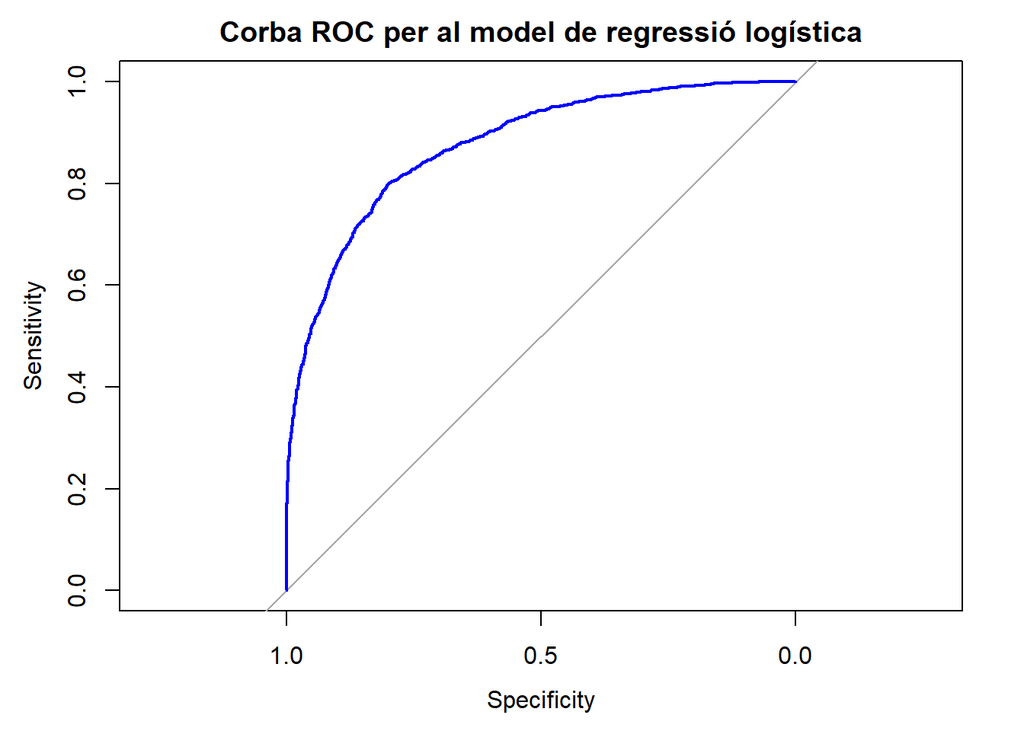

```r
plot(roc_obj, main = "Corba ROC per al model de regressió logística", col = "blue")
```

```r
# AUC
auc_value <- auc(roc_obj)
print(paste("Àrea sota la corba (AUC): ", auc_value))
```

```
## [1] "Àrea sota la corba (AUC):  0.875494193943"
```

Que la corba ROC estigui lluny de la diagonal ens indica que no és una classificació aleatòria, a més, la corba es corba cap a la part superior esquerra, indicant un bon equilibri entre sensibilitat i especificitat.

Un valor AUC de 0.875 ens indica que el model és molt bo distingint entre habitatges amb preu superior i inferior als 500000€ (87.5% dels casos).

# Resum i conclusions de l’anàlisi

Aquestes conclusions són útils per agències i professionals del mercat immobiliari per predir l’evolució dels preus i comprendre millor els factors clau en la valoració dels habitatges.